# Homework Vignette

### Answer9：

- **Q1**

  **A-B-O blood type problem**

  Obsered data: $n_{A\cdot}$,$n_{B\cdot}$,$n_{OO}$

  Complete data: $n_{AA}$,$n_{BB}$,$n_{OO}$,$n_{AO}$,$n_{BO}$,$n_{AB}$

  According to the question,
  $$p+q+r=1$$

  **Rcode and results:**

```r
library(nloptr)
#Maximum likelihood estimation
#objective function
f.ob = function(x_mstep,x_estep,n_A,n_B,nOO,nAB)
{

  #E-step
  r_estep = 1-sum(x_estep)
  nAA = n_A*x_estep[1]^2/(x_estep[1]^2+2*x_estep[1]*r_estep)
  nBB = n_B*x_estep[2]^2/(x_estep[2]^2+2*x_estep[2]*r_estep)
  #M-step
  r_mstep = 1-sum(x_mstep)
  l1 <- 2*nAA*log(x_mstep[1])+2*nBB*log(x_mstep[2])+2*nOO*log(r_mstep)
  l2 <- (n_A-nAA)*log(2*x_mstep[1]*r_mstep)+(n_B-nBB)*log(2*x_mstep[2]*r_mstep)+nAB*log(2*x_mstep[1]*x_mstep[2])
  #log-likelihood function
  ll <- l1+l2
  return(-ll)
}
#Constraint condition
f.cc <- function(x_mstep,x_estep,n_A,n_B,nOO,nAB)
{
  return(sum(x_mstep)-0.9999999)
}
para <- matrix(0,1,2)
#p0 and q0
para <- rbind(para,c(0.25,0.15))
EM <- NULL
i <- 2
while (mean(abs(para[i,]-para[i-1,]))>1e-8)
{
  res <- nloptr( x0=c(0.32,0.12),eval_f = f.ob,
                 lb = c(0,0), ub = c(1,1),
                 eval_g_ineq = f.cc,
                 ##a fractional tolerance xtol_rel
                 opts = list("algorithm"="NLOPT_LN_COBYLA","xtol_rel"=1.0e-8),
                 x_estep=para[i,],n_A=444,n_B=132,nOO=361,nAB=63)
  para <- rbind(para,res$solution)
  EM <- c(EM,res$objective)
  i <- i+1
}
#EM algorithm estimate
print(para[-1,])
```

```
#>            [,1]      [,2]
#>  [1,] 0.2500000 0.1500000
#>  [2,] 0.2917759 0.1048333
#>  [3,] 0.2967244 0.1027752
#>  [4,] 0.2974819 0.1027027
#>  [5,] 0.2976122 0.1027048
#>  [6,] 0.2976355 0.1027060
#>  [7,] 0.2976397 0.1027062
#>  [8,] 0.2976405 0.1027062
#>  [9,] 0.2976406 0.1027063
#> [10,] 0.2976407 0.1027063
#> [11,] 0.2976407 0.1027063
```

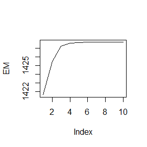

```r
#Objective function value
plot(EM,type = 'l')
```

- **Exercise11.1.2.3**

```r
library(base)
formulas <- list(#four models
  mpg ~ disp,
  mpg ~ I(1 / disp),
  mpg ~ disp + wt,
  mpg ~ I(1 / disp) + wt
)
data("mtcars")
attach(mtcars)
#using loop
Models1 <-  vector("list", length(formulas))
for (i in 1:length(formulas))
  Models1[[i]] <- lm(formulas[[i]], data = mtcars)
print(Models1)
```

```
#> [[1]]
#>
#> Call:
#> lm(formula = formulas[[i]], data = mtcars)
#>
#> Coefficients:
#> (Intercept)         disp
#>    29.59985     -0.04122
#>
#>
#> [[2]]
#>
#> Call:
#> lm(formula = formulas[[i]], data = mtcars)
#>
#> Coefficients:
#> (Intercept)    I(1/disp)
#>       10.75      1557.67
#>
#>
#> [[3]]
#>
#> Call:
#> lm(formula = formulas[[i]], data = mtcars)
#>
#> Coefficients:
#> (Intercept)         disp           wt
#>    34.96055     -0.01772     -3.35083
#>
#>
#> [[4]]
#>
#> Call:
#> lm(formula = formulas[[i]], data = mtcars)
#>
#> Coefficients:
#> (Intercept)    I(1/disp)           wt
#>      19.024     1142.560       -1.798
```

```r
# using lapply
Models2 <- lapply(X = formulas, FUN = function(model){ y <- lm(model, data = mtcars)})
# print the models in list
print(Models2)
```

```
#> [[1]]
#>
#> Call:
#> lm(formula = model, data = mtcars)
#>
#> Coefficients:
#> (Intercept)         disp
#>    29.59985     -0.04122
#>
#>
#> [[2]]
#>
#> Call:
#> lm(formula = model, data = mtcars)
#>
#> Coefficients:
#> (Intercept)    I(1/disp)
#>       10.75      1557.67
#>
#>
#> [[3]]
#>
#> Call:
#> lm(formula = model, data = mtcars)
#>
#> Coefficients:
#> (Intercept)         disp           wt
#>    34.96055     -0.01772     -3.35083
#>
#>
#> [[4]]
#>
#> Call:
#> lm(formula = model, data = mtcars)
#>
#> Coefficients:
#> (Intercept)    I(1/disp)           wt
#>      19.024     1142.560       -1.798
```

- **Exercise11.2.5.3**

```r
###12.3
set.seed(123)
trials <- replicate(
  #generate 100 p values
  100,
  #use 10+7 Poisson random values to generate one p value
  t.test(rpois(10, 10), rpois(7, 10)),
  simplify = FALSE
)
p.value1 <- sapply(1:length(trials), function(index) trials[[index]]$p.value)
p.value2 <- sapply(trials, function(X) X[['p.value']])
# [[ is a function return trials[[]]
p.value3 <- sapply(trials, '[[', 'p.value')
#Returns the first parts (10)
print(p.value1)
```

```
#>   [1] 9.813226e-01 1.619096e-05 6.242135e-01 6.693526e-01 5.677105e-01
#>   [6] 6.610740e-01 5.951636e-01 5.005347e-01 4.763110e-01 3.429965e-01
#>  [11] 8.155394e-01 7.197238e-01 1.244336e-01 2.229164e-01 1.113099e-02
#>  [16] 4.625765e-01 6.515865e-01 1.658793e-01 9.342672e-01 8.011934e-01
#>  [21] 4.627657e-01 5.927934e-01 2.929669e-01 5.737967e-01 3.451537e-02
#>  [26] 2.739138e-01 2.656151e-01 8.196695e-01 6.647355e-01 8.056529e-01
#>  [31] 5.060850e-01 7.106543e-01 2.321066e-01 1.106223e-01 5.459279e-01
#>  [36] 1.865470e-02 2.433776e-01 2.688851e-01 9.819256e-01 4.940184e-01
#>  [41] 3.268275e-01 8.000439e-01 9.822499e-01 1.936454e-01 7.390101e-01
#>  [46] 3.888930e-02 4.350424e-01 7.434339e-02 5.787441e-01 4.864951e-01
#>  [51] 1.476288e-01 5.524909e-01 7.129280e-01 8.683479e-03 9.053256e-02
#>  [56] 4.415463e-01 4.955063e-01 1.745328e-01 6.615399e-01 4.479199e-01
#>  [61] 2.885849e-01 3.028567e-02 1.018907e-01 1.811861e-02 6.376441e-01
#>  [66] 1.408742e-02 9.008128e-02 4.515933e-01 8.703291e-01 7.250768e-01
#>  [71] 8.183571e-01 8.465036e-01 8.786838e-01 1.651543e-01 3.951569e-01
#>  [76] 1.754280e-01 3.649865e-01 7.224226e-02 6.565152e-01 9.946559e-01
#>  [81] 3.715952e-01 8.424336e-02 4.549887e-01 8.530113e-01 1.970777e-01
#>  [86] 2.298117e-01 1.148832e-01 7.769502e-01 4.934348e-01 3.526049e-01
#>  [91] 2.036013e-01 8.838914e-01 6.474880e-02 4.089082e-01 5.780132e-01
#>  [96] 8.011408e-01 5.956061e-01 9.266689e-01 9.923205e-02 1.763972e-01
```

```r
print(p.value2)
```

```
#>   [1] 9.813226e-01 1.619096e-05 6.242135e-01 6.693526e-01 5.677105e-01
#>   [6] 6.610740e-01 5.951636e-01 5.005347e-01 4.763110e-01 3.429965e-01
#>  [11] 8.155394e-01 7.197238e-01 1.244336e-01 2.229164e-01 1.113099e-02
#>  [16] 4.625765e-01 6.515865e-01 1.658793e-01 9.342672e-01 8.011934e-01
#>  [21] 4.627657e-01 5.927934e-01 2.929669e-01 5.737967e-01 3.451537e-02
#>  [26] 2.739138e-01 2.656151e-01 8.196695e-01 6.647355e-01 8.056529e-01
#>  [31] 5.060850e-01 7.106543e-01 2.321066e-01 1.106223e-01 5.459279e-01
#>  [36] 1.865470e-02 2.433776e-01 2.688851e-01 9.819256e-01 4.940184e-01
#>  [41] 3.268275e-01 8.000439e-01 9.822499e-01 1.936454e-01 7.390101e-01
#>  [46] 3.888930e-02 4.350424e-01 7.434339e-02 5.787441e-01 4.864951e-01
#>  [51] 1.476288e-01 5.524909e-01 7.129280e-01 8.683479e-03 9.053256e-02
#>  [56] 4.415463e-01 4.955063e-01 1.745328e-01 6.615399e-01 4.479199e-01
#>  [61] 2.885849e-01 3.028567e-02 1.018907e-01 1.811861e-02 6.376441e-01
#>  [66] 1.408742e-02 9.008128e-02 4.515933e-01 8.703291e-01 7.250768e-01
#>  [71] 8.183571e-01 8.465036e-01 8.786838e-01 1.651543e-01 3.951569e-01
#>  [76] 1.754280e-01 3.649865e-01 7.224226e-02 6.565152e-01 9.946559e-01
#>  [81] 3.715952e-01 8.424336e-02 4.549887e-01 8.530113e-01 1.970777e-01
#>  [86] 2.298117e-01 1.148832e-01 7.769502e-01 4.934348e-01 3.526049e-01
#>  [91] 2.036013e-01 8.838914e-01 6.474880e-02 4.089082e-01 5.780132e-01
#>  [96] 8.011408e-01 5.956061e-01 9.266689e-01 9.923205e-02 1.763972e-01
```

```r
print(p.value3)
```

```
#>   [1] 9.813226e-01 1.619096e-05 6.242135e-01 6.693526e-01 5.677105e-01
#>   [6] 6.610740e-01 5.951636e-01 5.005347e-01 4.763110e-01 3.429965e-01
#>  [11] 8.155394e-01 7.197238e-01 1.244336e-01 2.229164e-01 1.113099e-02
#>  [16] 4.625765e-01 6.515865e-01 1.658793e-01 9.342672e-01 8.011934e-01
#>  [21] 4.627657e-01 5.927934e-01 2.929669e-01 5.737967e-01 3.451537e-02
#>  [26] 2.739138e-01 2.656151e-01 8.196695e-01 6.647355e-01 8.056529e-01
#>  [31] 5.060850e-01 7.106543e-01 2.321066e-01 1.106223e-01 5.459279e-01
#>  [36] 1.865470e-02 2.433776e-01 2.688851e-01 9.819256e-01 4.940184e-01
#>  [41] 3.268275e-01 8.000439e-01 9.822499e-01 1.936454e-01 7.390101e-01
#>  [46] 3.888930e-02 4.350424e-01 7.434339e-02 5.787441e-01 4.864951e-01
#>  [51] 1.476288e-01 5.524909e-01 7.129280e-01 8.683479e-03 9.053256e-02
#>  [56] 4.415463e-01 4.955063e-01 1.745328e-01 6.615399e-01 4.479199e-01
#>  [61] 2.885849e-01 3.028567e-02 1.018907e-01 1.811861e-02 6.376441e-01
#>  [66] 1.408742e-02 9.008128e-02 4.515933e-01 8.703291e-01 7.250768e-01
#>  [71] 8.183571e-01 8.465036e-01 8.786838e-01 1.651543e-01 3.951569e-01
#>  [76] 1.754280e-01 3.649865e-01 7.224226e-02 6.565152e-01 9.946559e-01
#>  [81] 3.715952e-01 8.424336e-02 4.549887e-01 8.530113e-01 1.970777e-01
#>  [86] 2.298117e-01 1.148832e-01 7.769502e-01 4.934348e-01 3.526049e-01
#>  [91] 2.036013e-01 8.838914e-01 6.474880e-02 4.089082e-01 5.780132e-01
#>  [96] 8.011408e-01 5.956061e-01 9.266689e-01 9.923205e-02 1.763972e-01
```

- **Exercise11.2.5.6**

```r
#a variant of lapply()
vari.lapply<-function (f,n,data_type, ...)
{
#to match as function
f<-match.fun(FUN = f, descend = TRUE)
f1 <- Map(f, ...)
#logical < integer < double < complex < character
if(data_type == "character")     res <- vapply(f1,cbind,FUN.VALUE = character(n))
else if(data_type == "complex")  res <- vapply(f1,cbind,FUN.VALUE = complex(n))
else if(data_type == "numeric")  res <- vapply(f1,cbind,FUN.VALUE = numeric(n))
else if(data_type == "logical")  res <- vapply(f1,cbind,FUN.VALUE = logical(n))
return(res)
}
#Example(self-defining)
#matrix
set.seed(123)
f.xy <- function(x,y) {x>y}
x1<-list(runif(5,-1, 1), runif(5,-2,2))
x2<-list(rnorm(5), rnorm(5,0,1.5))
matrix1 <-vari.lapply(f.xy,n=5,data_type="logical",x1,x2)
print(matrix1)
```

```
#>       [,1]  [,2]
#> [1,] FALSE FALSE
#> [2,]  TRUE FALSE
#> [3,]  TRUE  TRUE
#> [4,]  TRUE  TRUE
#> [5,]  TRUE  TRUE
```

```r
#vector
set.seed(123)
y <- list(rnorm(5), rnorm(10))
vector1 <- vari.lapply(mean,n=1,data_type="numeric",y)
print(vector1)
```

```
#> [1] 0.1935703 0.1317914
```

## HW10

### Question10：

- **Exercise 9.4**

  Implement a random walk Metropolis sampler for generating the standard Laplace distribution (see Exercise 3.2). For the increment, simulate from a normal distribution. Compare the chains generated when different variances are used for the proposal distribution. Also, compute the acceptance rates of each chain.
- Write an Rcpp function for Exercise 9.4 (page 277, Statistical Computing with R).
- Compare the corresponding generated random numbers with those by the R function you wrote before using the function “qqplot”.
- Campare the computation time of the two functions with the function “microbenchmark”.
- Comments your results.

### Answer10：

- **Exercise 9.4**

The standard Laplace distribution has density
$$f(x) = \frac{1}{2} e^{−|x|}, x ∈ R$$

**1.R function for random walk Metropolis sampler**

```r
#the standard Laplace distribution*2
pdf.Laplace_R <- function(x){
  return(exp(-1*abs(x)))
}
#
rw.Metro_R <-function(sigma,N,x_initial){
 u <- runif(N)
 x <- numeric(N)
 x[1] <- x_initial
 k <- 0
 for (i in 2:N){
    y <- rnorm(1,x[i-1],sigma)
    if(u[i] <= (pdf.Laplace_R(y)/pdf.Laplace_R(x[i-1]))){
     x[i] <- y
    }
    else{
     x[i] <- x[i-1]
     k <- k+1
 }
 return (list(x=x,k))
}
```

**2.Rcpp function for random walk Metropolis sampler**

```r
#include <Rcpp.h>
using namespace Rcpp;
// [[Rcpp::export]]
double pdfLaplaceC(double x)
{
  return exp(-1*abs(x));
 }
// [[Rcpp::export]]
List rwMetroC(double sigma, int N, double xinitial){
  NumericVector u = runif(N);
  NumericVector x(N);
  x[0] = xinitial;
  int k = 0;
  NumericVector y;
  for(int i = 1;i <= (N-1);i++){
    y = rnorm(1, x[i-1], sigma);
    if (u[i] <= (pdfLaplaceC(y[0])/pdfLaplaceC(x[i-1]))) {
      x[i] = y[0];
    }
    else {
      x[i] = x[i-1];
      k++;
    }
  }
  List res = List::create(x,k);
  return (res);
}
```

**Campare the computation time**

```r
#the standard Laplace distribution*2
pdf.Laplace_R <- function(x){
  return(exp(-1*abs(x)))
}
#
rw.Metro_R <-function(sigma,N,x_initial){
 u <- runif(N)
 x <- numeric(N)
 x[1] <- x_initial
 k <- 0
 for (i in 2:N){
    y <- rnorm(1,x[i-1],sigma)
    if(u[i] <= (pdf.Laplace_R(y)/pdf.Laplace_R(x[i-1]))){
     x[i] <- y
    }
    else{
      x[i] <- x[i-1]
      k <- k+1
    }
 }
 return (list(x=x,k))
}
library(Rcpp)
library(microbenchmark)
sourceCpp(
  code='
  #include<Rcpp.h>
  using namespace Rcpp;
  // [[Rcpp::export]]
  double pdfLaplaceC(double x)
  {
    return exp(-1*abs(x));
  }
  // [[Rcpp::export]]
  List rwMetroC(double sigma, int N, double xinitial){
    NumericVector u = runif(N);
    NumericVector x(N);
    x[0] = xinitial;
    int k = 0;
    NumericVector y;
    for(int i = 1;i <= (N-1);i++){
      y = rnorm(1, x[i-1], sigma);
      if (u[i] <= (pdfLaplaceC(y[0])/pdfLaplaceC(x[i-1]))) {
        x[i] = y[0];
      }
      else {
        x[i] = x[i-1];
        k++;
    }
    }
    List res = List::create(x,k);
    return (res);
  }
  '
)
# Campare the computation time when sigma = 2
runtime<-microbenchmark(list_R=rw.Metro_R(2,200,25),list_C=rwMetroC(2,200,25))
summary(runtime)
```

```
#>     expr   min     lq    mean median     uq     max neval
#> 1 list_R 654.3 671.55 995.383 691.15 773.45 17929.4   100
#> 2 list_C  38.1  41.65  59.516  44.25  46.70  1251.8   100
```

RCpp function runs faster than R function.

**QQplot**

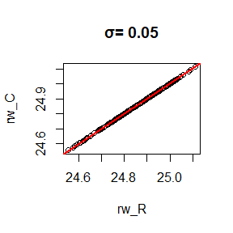

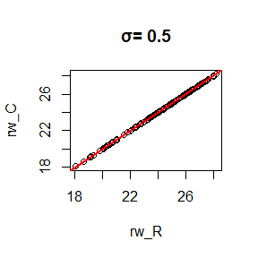

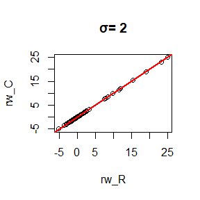

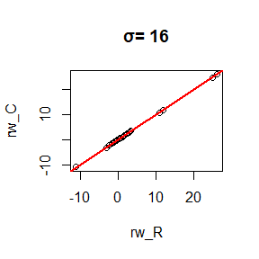

```r
set.seed(12345)
n <- 4
sigma<-c(0.05,0.5,2,16)
N <- 200
x0 <- 25
X_R <- X_C<- matrix(nrow = N ,ncol = n)
rej.rateR <- rej.rateC <- numeric(n)
#par(mfrow=c(2,2))
for (i in 1:n){
  rw_R <- rw.Metro_R(sigma[i],N,x0)
  rw_C <- rwMetroC(sigma[i],N,x0)
  X_R[,i]<- rw_R[[1]]
  X_C[,i]<- rw_C[[1]]
  qqplot(rw_R[[1]],rw_R[[1]],xlab = "rw_R",ylab = "rw_C",main = paste("σ=",sigma[i]))
  abline(a = 0,b = 1,col = 2, lwd = 2)
  rej.rateR[i]<-rw_R[[2]]/N
  rej.rateC[i]<-rw_C[[2]]/N
}
```

The points in the figure are all close to the line $y=x$.

**The results**

```r
library(knitr)
kable(data.frame(sigma = sigma,reject.rate_R = rej.rateR,reject.rate_C = rej.rateC))
```

| sigma | reject.rate_R | reject.rate_C |
| --- | --- | --- |
| 0.05 | 0.035 | 0.010 |
| 0.50 | 0.165 | 0.145 |
| 2.00 | 0.420 | 0.370 |
| 16.00 | 0.865 | 0.830 |

Thus,the random numbers generated are generally similar but not identical.